# Homework 06

Data Management with SQL

There are three problems this week, the first two dealing with SQL grouping, and the third dealing with data modeling. For the first two problems, the repository contains a zip file which can be used to recreate a collection of tables of airplane flights over the month of January, 2020. If you are interested in more, similar type data, I grabbed the original data from the Bureau of Transportation Statistics [here](https://www.transtats.bts.gov/TableInfo.asp?gnoyr_VQ=FGJ&QO_fu146_anzr=b0-gvzr&V0s1_b0yB=D).

[Accept Assignment](https://classroom.github.com/a/_tBZFuvb)

In the repository lives a zip file named `hw6.zip`. You should download that zip file and extract it, which has inside two SQL files (compressing made them small enough to upload to GitHub). These `.sql` files are a bit different from what you have seen in the past though, as they are technically a *database dump*. These are a common way to generate exact duplicates of the contents of a database. *However*, interacting with them can have some differences. The easiest, and fastest, method is to use the command line (terminal) tool `psql` that should have been installed along with the rest of PostgreSQL at the start of the semester (though it may or may not have gotten correctly added to your system PATH). If you open a terminal (or command prompt) at the location of the `hw6_fast.sql` file (or open a terminal anywhere and then navigate to that location), the command that you want to run is simply:

```bash
psql -d analysis -U yourusername -f hw6_fast.sql
```

where `analysis` is presumably the name of the database where you’ve been placing everything, and `yourusername` is whatever user-name you’ve been using with your database. If you happened to set up the database server on a non-default port, you’ll also need to include `-p portnum`. Assuming all goes successfully, this will create a new `hw6` schema in your `analysis` database and set up the 6 different tables, complete with data, constraints, and primary and foreign keys. You should be able to confirm this by opening whatever client you usually use and querying the tables.

If this is not working, for whatever reason, I’ve tried to give you another option as well. The `hw6_slow.sql` file is also a database dump, but one which has been tweaked to use standard `INSERT INTO` statements. The result is that you should be able to run this file like any other collection of SQL commands in your client, but the price is that it will be MUCH slower to populate the initial tables. I’d recommend the first option if possible, but if you are having absolutely no luck getting `psql` to work in the terminal, I think this will work. *If you are still having trouble getting the tables generated, please reach out! I’m happy to help you through this!*

The benefit of loading a database dump, of course, is that the database structure is all ready for you, with a central table `flights` having information about individual flights as well as references to other tables with information about airports, carriers, and city markets (to name a few). An image of the ERD is included below, as well as in the repository, for your reference, or you can look at the version online [here](https://drawsql.app/wu-data-engineering/diagrams/airline-flights).

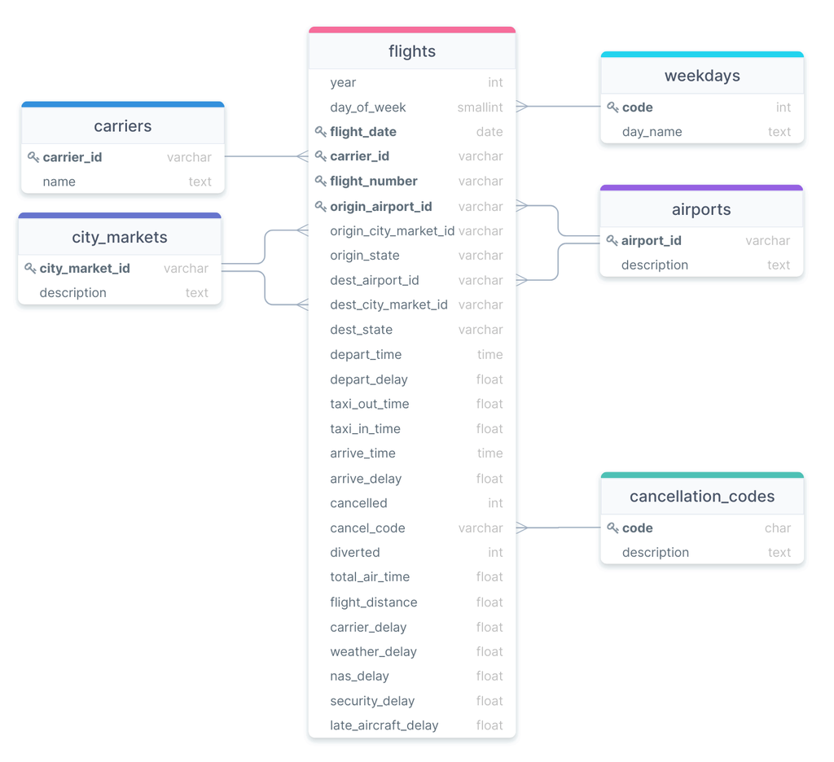

Entity Relationship Diagram of the airlines database table structure.

# Problem 1: Birds of a Feather

This initial batch of questions will focus on being able to use keywords such as `GROUP BY` effectively. For each you should **include any queries you used** to determine the answer, as well as the answer itself. *You may need several queries or temporary tables to answer some parts. Show all your work.*

1. What is the name of the airport which, over the given month’s data, has the greatest average delay in arriving flights? Limit your answer to only include airports with at least 100 arriving flights over the course of the month.
2. Which 3 US cities have the greatest number of inbound flights across all airports serving that city? (Some cities have multiple airports, which is what the `city_market_id` is supposed to assist with.)
3. Which 5 airports have the greatest number of outgoing flights *per day* on average? How many flights (on average) are leaving those airports each day?
4. For each major airline carrier, which two airports represent the endpoints of that carrier’s longest flight (by distance)? There are 17 distinct carriers in the month represented in the dataset, so your output table should also have 17 rows with the name of the carrier and the name of both airports. Dealing with round trip duplicates here can be a little tricky, so think about how you could reliably filter out one of the directions. It doesn’t matter whether you choose PDX to SEA or SEA to PDX (for instance), you just need one of the pairings for each carrier. Export the results to a CSV named `longest_flights.csv` with a header and **upload it back to GitHub**.

# Problem 2: Some Plane Visualization

Just looking at the numeric outputs from our queries isn’t always the most enlightening. Sometimes a little data visualization goes a long way. Depending on what you have done in the past, you may have a host of data visualization tools in your toolbox, ranging from R through Python to Excel. Any are completely appropriate for the following questions, but regardless of what software you use, ensure that your charts have clearly labeled axes and a title describing what they depict. You may need to save the output of your query in a format that your visualization software can understand (frequently CSV).

1. Create a simple bar chart showing the total number of departing flights each day of the week.
2. This second part is more open-ended. Define a question that you are interested in investigating in this current data set. There is lots of potential data here that I haven’t already asked questions about that might be interesting! The only requirement is that you must use `GROUP BY` in the course of answering your question, and you must include a visualization to help you answer the question. Clearly state both your question, your work to answer the question, and your visualization in your submission.

# Problem 3: That’s Not Normal

One of the more common ways that you will receive non-normalized data is through various JSON formats. Consider then the example JSON response shown below, which might depict a response from an internal API containing information about student assignment submissions and corresponding feedback and rubric items.

```python
[
  {
    "student_id": "2948294",
    "name": "Janet",
    "submitted_date": "2022-09-22",
    "assignment": "Homework 1",
    "total_available_points": 20,
    "deductions": [
      {
          "id": 1,
          "comment": "Didn't read instructions well",
          "deduction": -1
      },
      {
          "id": 2,
          "comment": "Missed a negative",
          "deduction": -0.5
      }
    ]
  }, ...etc...
]
```

The repository has a more complete example that you can look through, which includes multiple submissions. *Note that you can have the same deduction item showing up multiple times for a given assignment.* Your task here is to take this information and progressively create from it tables of various normal forms. I will not ask you to show the specific contents within these tables, but am instead just interested in the structure of the tables. As such, the easiest way to represent table structure (and potential relations between tables) is through ER Diagrams. For each of the below parts, I’d ask you to upload an ER diagram created by a tool such as DrawSQL to the repository.

1. The first step is always to get the data / table into the first normal form. As a reminder, in this form you just need to have 1 piece of information per cell, and have some primary or compound primary key that uniquely identifies each row of the table. Create an ERD for a table that would hold the above data. This will be just a single table in this case, so you really just need to worry about specifying the column names and types, as well as determining what your primary key will be.
2. To put the table into 2NF, you need to ensure that there are no partial dependencies present, where some columns only depend on a subset of the columns that comprise a compound primary key. If you do not have a compound primary key, then your table is already in 2NF. Break the above into more tables as necessary to ensure that you no longer have any partial dependencies in any table. Be sure to include in the ERD which tables and columns are related to others through foreign key dependencies.
3. Finally, to ensure that your tables are in 3NF, you must ensure that there are no transitive dependencies, where one column actually depends on another (non-primary key) column, instead of the primary key. Continue to break apart your tables as necessary to ensure that there are no transitive dependencies between any non-primary key columns. Again, be sure to include in your ERD the foreign key constraints that indicate what rows are related.

Don’t forget to include an image of the ERD for *each step* of the process above! If you could upload them back to GitHub with names like `Prob3_1NF.png`, `Prob3_2NF.png`, and `Prob3_3NF.png`, that would be very appreciated!